# Slide Presentation

March 15, 2018

## Introduction

In this project, we will

1. read, clean, and organize the data from the website for NOAA Weather Station buoy 46035 at 57.026 N 177.738 W in the NOAA National Data Buoy Center
2. produce a time series composed of 30 years of daily Air Temperature and Sea Temperature readings recorded at noon
3. visualize and explore the correlation between air temperature and sea temperature
4. test whether the mean temperature changed over the past 30 years

## Time Series for Air Temperature

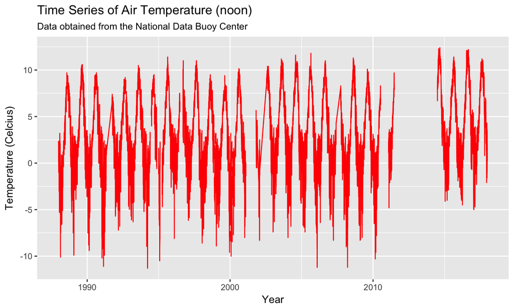

## Time Series for Sea Temperature

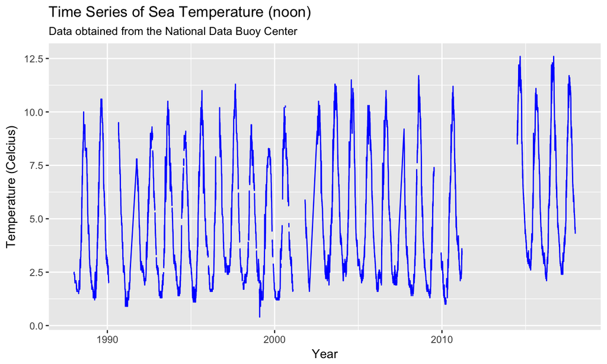

## Time Series for Air and Sea Temperatures

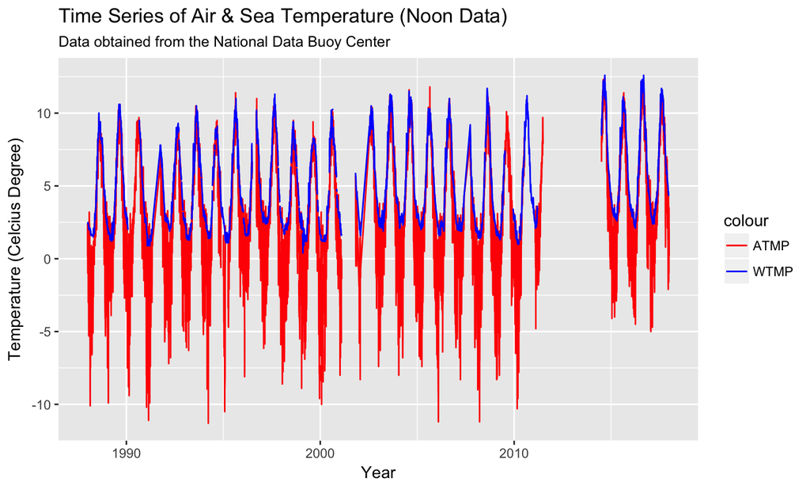

## Scatter Plot to See the Correlation between ATMP and WTMP

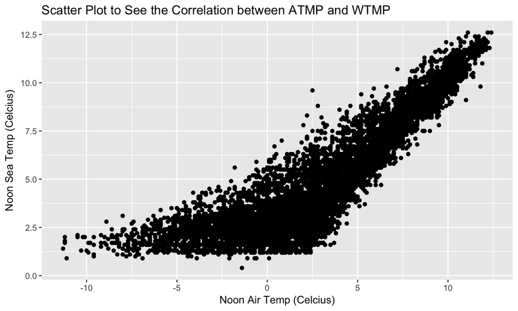

## Smooth Line to See the Correlation between ATMP and WTMP

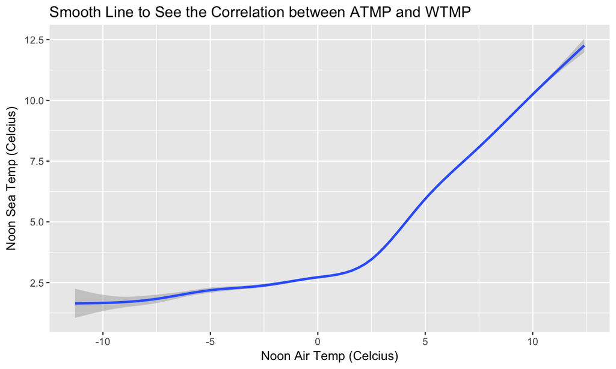

## Air and Sea Temperature Correlation

```
##
##  Pearson's product-moment correlation
##
## data:  noon$ATMP and noon$WTMP
## t = 163.7, df = 8005, p-value < 2.2e-16
## alternative hypothesis: true correlation is not equal to 0
## 95 percent confidence interval:
##  0.8723586 0.8824382
## sample estimates:
##       cor
## 0.8774953
```

## Test Whether Air Temperature Changed from 1988 to 2017 (Noon_Data)

Because the p-value = 5.153e-13 < 0.01, we reject the null hypothesis that the means of ATMP in 1988 and in 2017 are equal, so the air temp changed over 30 years. Means in two years:2.330748 4.645179

## Test Whether Sea Temperature Changed from 1988 to 2017 (Noon_Data)

Because the p-value = 9.035e-13 < 0.01, we reject the null hypothesis that the means of WTMP in 1988 and in 2017 are equal,so the sea temp changed over 30 years. Means in two years: 4.572981 6.141525

## Test Whether Air Temperature Changed from 1988 to 2017 (Total Data)

Because the p-value < 2.2e-16 < 0.01, we reject the null hypothesis that the means of ATMP in 1988 and in 2017 are equal,so air temp changed over 30 years. Means in two years: 2.438602 4.714333

## Test Whether Sea Temperature Changed from 1988 to 2017 (Total Data)

Because the p-value < 2.2e-16 < 0.01, we reject the null hypothesis that the means of WTMP in 1988 and in 2017 are equal,so sea temp changed over 30 years. Means in two years: 4.608660 6.156853